# assignment 1

Yu Gong

2023-09-24

## Question 1

Load the data Auto after installing and loading the library ISLR2. and complete the following parts.

```r
library(ISLR2)
?Auto
```

```
## 打开httpd帮助服务器… 好了
```

### (a) Look up the help for Auto. (b) Compute the dimension size of Auto and display its dimension names.

```r
dim(Auto)
```

```
## [1] 392   9
```

```r
names(Auto)
```

```
## [1] "mpg"          "cylinders"    "displacement" "horsepower"   "weight"
## [6] "acceleration" "year"         "origin"       "name"
```

### (c) Write an expression that returns the summary statistics, as given by summary(),for each of the first eight columns in this matrix.

```r
summary(Auto[,1:8])
```

```
##       mpg          cylinders      displacement     horsepower        weight
##  Min.   : 9.00   Min.   :3.000   Min.   : 68.0   Min.   : 46.0   Min.   :1613
##  1st Qu.:17.00   1st Qu.:4.000   1st Qu.:105.0   1st Qu.: 75.0   1st Qu.:2225
##  Median :22.75   Median :4.000   Median :151.0   Median : 93.5   Median :2804
##  Mean   :23.45   Mean   :5.472   Mean   :194.4   Mean   :104.5   Mean   :2978
##  3rd Qu.:29.00   3rd Qu.:8.000   3rd Qu.:275.8   3rd Qu.:126.0   3rd Qu.:3615
##  Max.   :46.60   Max.   :8.000   Max.   :455.0   Max.   :230.0   Max.   :5140
##   acceleration        year           origin
##  Min.   : 8.00   Min.   :70.00   Min.   :1.000
##  1st Qu.:13.78   1st Qu.:73.00   1st Qu.:1.000
##  Median :15.50   Median :76.00   Median :1.000
##  Mean   :15.54   Mean   :75.98   Mean   :1.577
##  3rd Qu.:17.02   3rd Qu.:79.00   3rd Qu.:2.000
##  Max.   :24.80   Max.   :82.00   Max.   :3.000
```

### (d) Apply the pairs() function to the matrix to create scatter plots of the first eight columns against one another.

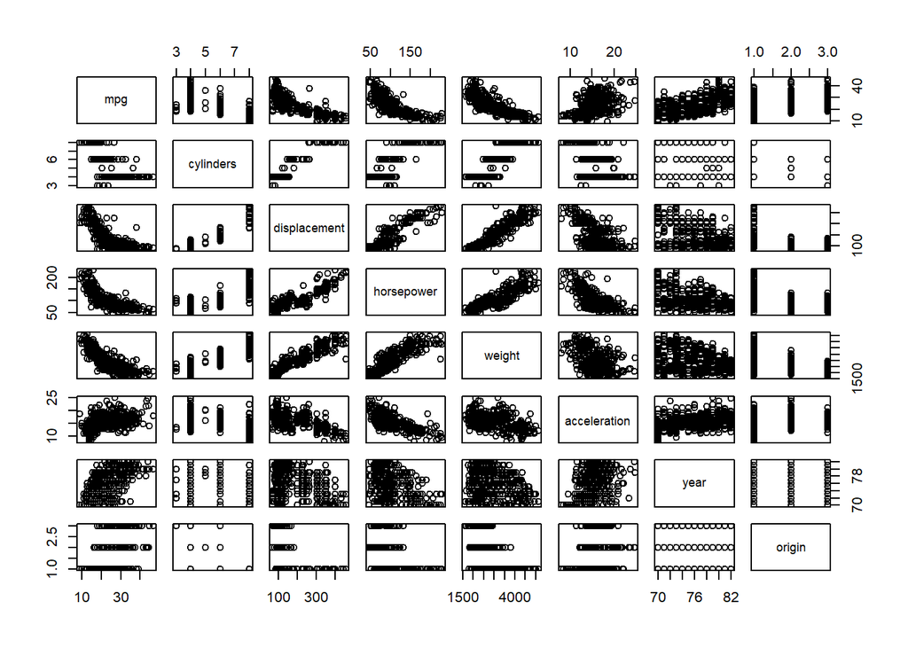

```r
pairs(Auto[,1:8])
```

### (e) Create a correlation matrix of the rst seven columns

```r
cor(Auto[,1:7])
```

```
##                     mpg  cylinders displacement horsepower     weight
## mpg           1.0000000 -0.7776175   -0.8051269 -0.7784268 -0.8322442
## cylinders    -0.7776175  1.0000000    0.9508233  0.8429834  0.8975273
## displacement -0.8051269  0.9508233    1.0000000  0.8972570  0.9329944
## horsepower   -0.7784268  0.8429834    0.8972570  1.0000000  0.8645377
## weight       -0.8322442  0.8975273    0.9329944  0.8645377  1.0000000
## acceleration  0.4233285 -0.5046834   -0.5438005 -0.6891955 -0.4168392
## year          0.5805410 -0.3456474   -0.3698552 -0.4163615 -0.3091199
##              acceleration       year
## mpg             0.4233285  0.5805410
## cylinders      -0.5046834 -0.3456474
## displacement   -0.5438005 -0.3698552
## horsepower     -0.6891955 -0.4163615
## weight         -0.4168392 -0.3091199
## acceleration    1.0000000  0.2903161
## year            0.2903161  1.0000000
```

### (f)Select the cars that have < 16 mpg, but having eight cylinders

```r
library(tidyverse)
Auto%>%
        filter(mpg<16,cylinders==8)
```

```
##     mpg cylinders displacement horsepower weight acceleration year origin
## 1  15.0         8          350        165   3693         11.5   70      1
## 2  15.0         8          429        198   4341         10.0   70      1
## 3  14.0         8          454        220   4354          9.0   70      1
## 4  14.0         8          440        215   4312          8.5   70      1
## 5  14.0         8          455        225   4425         10.0   70      1
## 6  15.0         8          390        190   3850          8.5   70      1
## 7  15.0         8          383        170   3563         10.0   70      1
## 8  14.0         8          340        160   3609          8.0   70      1
## 9  15.0         8          400        150   3761          9.5   70      1
## 10 14.0         8          455        225   3086         10.0   70      1
## 11 10.0         8          360        215   4615         14.0   70      1
## 12 10.0         8          307        200   4376         15.0   70      1
## 13 11.0         8          318        210   4382         13.5   70      1
## 14  9.0         8          304        193   4732         18.5   70      1
```

[output cut: 127 more lines]

```r
Auto[which(Auto$mpg<16 & Auto$cylinders==8),]
```

```
##      mpg cylinders displacement horsepower weight acceleration year origin
## 2   15.0         8          350        165   3693         11.5   70      1
## 6   15.0         8          429        198   4341         10.0   70      1
## 7   14.0         8          454        220   4354          9.0   70      1
## 8   14.0         8          440        215   4312          8.5   70      1
## 9   14.0         8          455        225   4425         10.0   70      1
## 10  15.0         8          390        190   3850          8.5   70      1
## 11  15.0         8          383        170   3563         10.0   70      1
## 12  14.0         8          340        160   3609          8.0   70      1
## 13  15.0         8          400        150   3761          9.5   70      1
## 14  14.0         8          455        225   3086         10.0   70      1
## 26  10.0         8          360        215   4615         14.0   70      1
## 27  10.0         8          307        200   4376         15.0   70      1
## 28  11.0         8          318        210   4382         13.5   70      1
## 29   9.0         8          304        193   4732         18.5   70      1
```

[output cut: 127 more lines]

```r
meanpower<-mean(Auto$horsepower)
meanweight<-mean(Auto$weight)
Auto%>%
        filter(horsepower>meanpower,weight>meanweight)
```

```
##      mpg cylinders displacement horsepower weight acceleration year origin
## 1   18.0         8          307        130   3504         12.0   70      1
## 2   15.0         8          350        165   3693         11.5   70      1
## 3   18.0         8          318        150   3436         11.0   70      1
## 4   16.0         8          304        150   3433         12.0   70      1
## 5   17.0         8          302        140   3449         10.5   70      1
## 6   15.0         8          429        198   4341         10.0   70      1
## 7   14.0         8          454        220   4354          9.0   70      1
## 8   14.0         8          440        215   4312          8.5   70      1
## 9   14.0         8          455        225   4425         10.0   70      1
## 10  15.0         8          390        190   3850          8.5   70      1
## 11  15.0         8          383        170   3563         10.0   70      1
## 12  14.0         8          340        160   3609          8.0   70      1
## 13  15.0         8          400        150   3761          9.5   70      1
## 14  14.0         8          455        225   3086         10.0   70      1
```

[output cut: 239 more lines]

### (h) Create a design matrix, X, that contains all 1’s in the first column and the hoursepower in the second column. This will serve as our design matrix in part (m).

```r
X<-cbind(rep(1,length(Auto$horsepower)),Auto$horsepower)
head(X)
```

```
##      [,1] [,2]
## [1,]    1  130
## [2,]    1  165
## [3,]    1  150
## [4,]    1  150
## [5,]    1  140
## [6,]    1  198
```

### (i) simple linear regression

```r
y<-as.matrix(Auto$mpg)
b<-solve(t(X)%*%X)%*%t(X)%*%y
b
```

```
##            [,1]
## [1,] 39.9358610
## [2,] -0.1578447
```

```r
fit<-lm(Auto$mpg~Auto$horsepower)
fit$coefficients
```

```
##     (Intercept) Auto$horsepower
##      39.9358610      -0.1578447
```

### (i) In a single plot, draw the following subplots (1) a scatter plot of mpg (y) versus horsepower (x); (2) a histogram of mpg; (3) a Quantile-Quantiale plot of mpg;(4) a boxplot of mpg and horsepower.

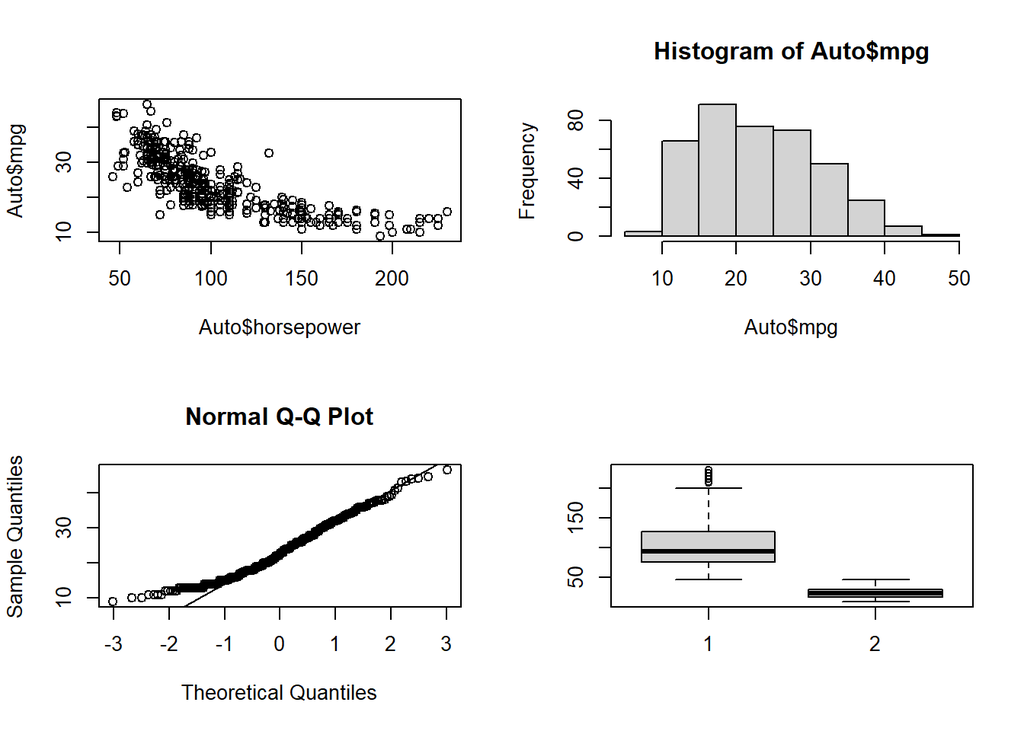

```r
par(mfrow=c(2,2))
plot(Auto$horsepower,Auto$mpg,type='p')
hist(Auto$mpg)
qqnorm(Auto$mpg)
qqline(Auto$mpg)
boxplot(Auto$horsepower,Auto$mpg)
```

## Question 2

```r
1-pnorm(3)
```

```
## [1] 0.001349898
```

```r
1-pnorm(35,30,4)
```

```
## [1] 0.1056498
```

```r
dbinom(10,10,0.83)
```

```
## [1] 0.1551604
```

```r
punif(0.9)
```

```
## [1] 0.9
```

```r
1-pchisq(6.5,df=2)
```

```
## [1] 0.03877421
```

## Question 3

### (a)

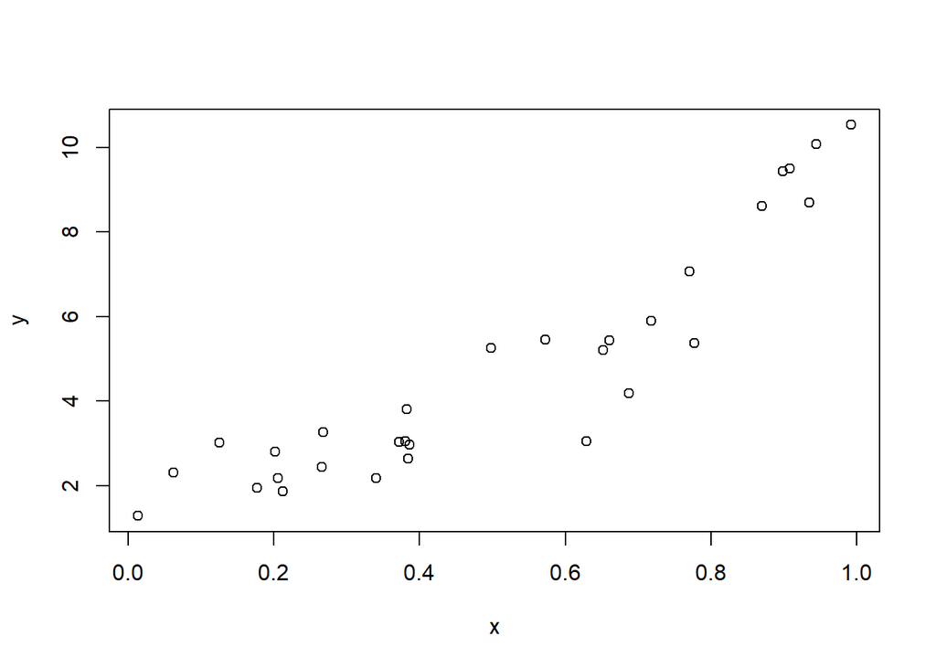

```r
set.seed(1)
x<-runif(30,0,1)
y<-1.5+3.1*x+1.2*x^2+4.5*x^3+rnorm(30,0,1)
train<-cbind(y,x)
train<-as.data.frame(train)
plot(x,y,type='p')
```

### (b)&(c)

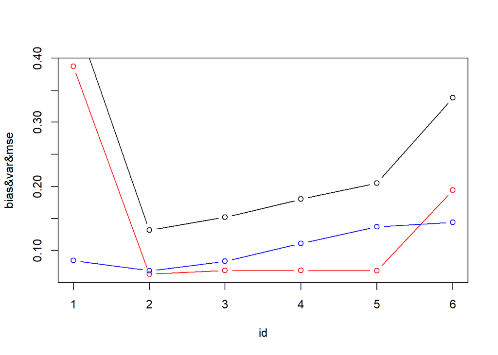

```r
x<-seq(0,1,length=100)
y<-1.5+3.1*x+1.2*x^2+4.5*x^3+rnorm(100,0,1)
test<-cbind(y,x)
test<-as.data.frame(test)
bias<-rep(0,6)
var<-rep(0,6)
mse<-rep(0,6)
id<-seq(1:6)
for (i in 1:6){
        fit<-lm(y~poly(x,i),data=train)
        predict_test<-predict.lm(fit,test,se.fit=TRUE,interval='none')
        bias[i]<-sum((predict_test$fit-(1.5+3.1*x+1.2*x^2+4.5*x^3))^2)/100
        var[i]<-sum((predict_test$se.fit)^2)/100
        mse[i]<-bias[i]+var[i]
}

plot(id,bias,type='b',col='red',ylab="bias&var&mse")
lines(id,var,type='b',col='blue')
lines(id,mse,type='b',col='black')
```

## Question 4

```r
comm<-read.table("CommercialProperties.txt", sep = "", header = TRUE)
```

### (a)

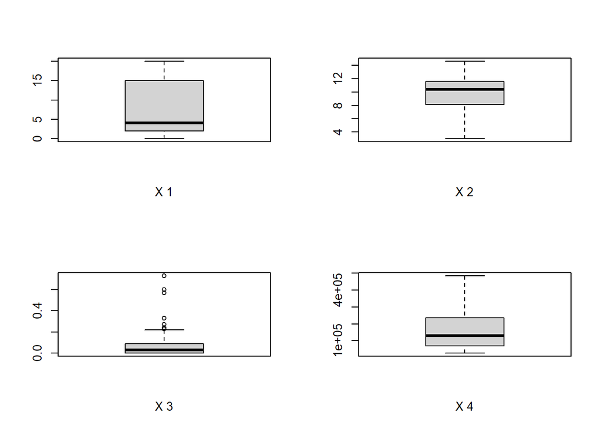

```r
par(mfrow=c(2,2))
for (i in 2:5){
        boxplot(comm[,i],xlab=paste("X",i-1))
}
```

### (b)

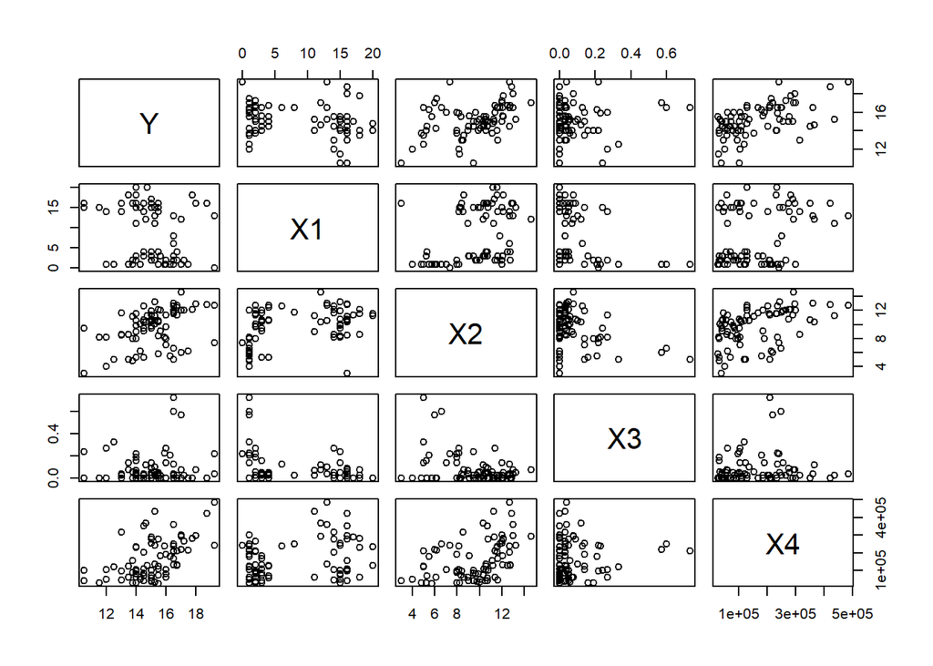

```r
pairs(comm[,1:5])
```

```r
cor_matrix<-cor(comm[,1:5])
cor_matrix
```

```
##              Y         X1         X2          X3         X4
## Y   1.00000000 -0.2502846  0.4137872  0.06652647 0.53526237
## X1 -0.25028456  1.0000000  0.3888264 -0.25266347 0.28858350
## X2  0.41378716  0.3888264  1.0000000 -0.37976174 0.44069713
## X3  0.06652647 -0.2526635 -0.3797617  1.00000000 0.08061073
## X4  0.53526237  0.2885835  0.4406971  0.08061073 1.00000000
```

Y doesn’t have significant linear relationship with X3; X2 and X4 has linear relationship to some extent (colinearity caveat)

### (c)

```r
fit<-lm(Y~X1+X2+X3+X4,data=comm)
summary(fit)
```

```
##
## Call:
## lm(formula = Y ~ X1 + X2 + X3 + X4, data = comm)
##
## Residuals:
##     Min      1Q  Median      3Q     Max
## -3.1872 -0.5911 -0.0910  0.5579  2.9441
##
## Coefficients:
##               Estimate Std. Error t value Pr(>|t|)
## (Intercept)  1.220e+01  5.780e-01  21.110  < 2e-16 ***
## X1          -1.420e-01  2.134e-02  -6.655 3.89e-09 ***
## X2           2.820e-01  6.317e-02   4.464 2.75e-05 ***
## X3           6.193e-01  1.087e+00   0.570     0.57
## X4           7.924e-06  1.385e-06   5.722 1.98e-07 ***
## ---
## Signif. codes:  0 '***' 0.001 '**' 0.01 '*' 0.05 '.' 0.1 ' ' 1
##
## Residual standard error: 1.137 on 76 degrees of freedom
## Multiple R-squared:  0.5847, Adjusted R-squared:  0.5629
## F-statistic: 26.76 on 4 and 76 DF,  p-value: 7.272e-14
```

### (d)

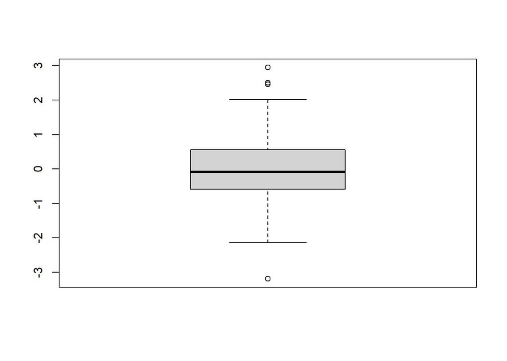

```r
boxplot(fit$residuals)
```

seems symmetric (https://en.wikipedia.org/wiki/Box_plot#/media/File:Boxplot_vs_PDF.svg)

### (e)

```r
test_comm = data.frame(X1=5,X2=8.25,X3=0,X4=250000)
pred_new_clim = predict.lm(fit, test_comm,se.fit=TRUE, interval =  "confidence")
pred_new_clim$fit[1] #predict of mean response
```

```
## [1] 15.79813
```

```r
pred_new_clim$se.fit #standard error of predicted mean
```

```
## [1] 0.2780832
```

```r
pred_new_clim$fit[2:3] #confidence interval of predicted mean
```

```
## [1] 15.24428 16.35198
```

## Question 5

### (a)

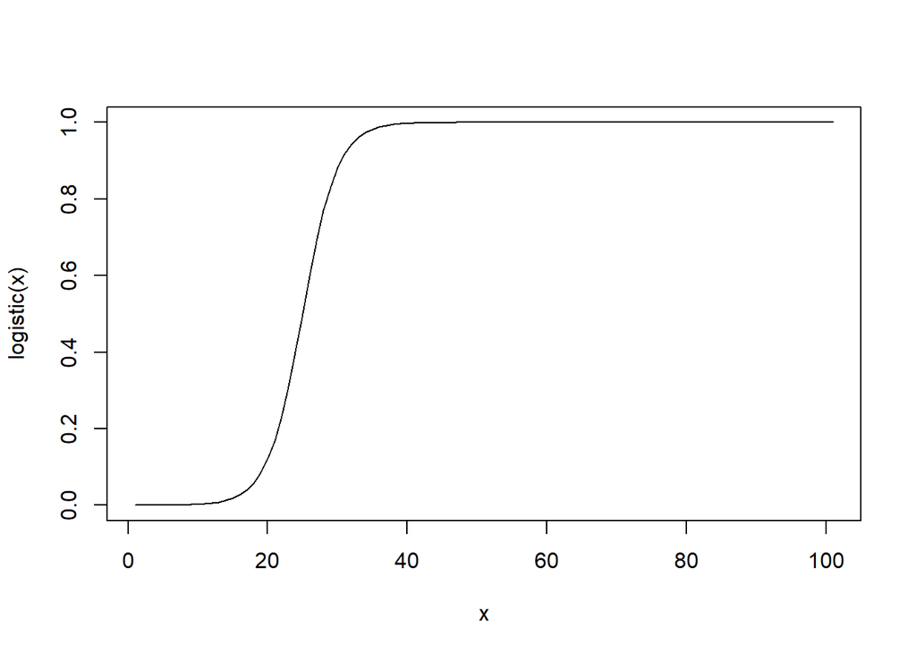

```r
x<-seq(0:100)
beta_0=-10
beta_1=0.4
logistic<-function(x){
        exp(beta_0+beta_1*x)/(exp(beta_0+beta_1*x)+1)
}
plot(x,logistic(x),type='l')
```

### (b) when Pai=0.5, it means ln(pai/1-pai)=beta_0+beta_1^x=0

```r
-beta_0/beta_1
```

```
## [1] 25
```

### (c)

```r
logistic(25)/(1-logistic(25))
```

```
## [1] 1
```

```r
logistic(26)/(1-logistic(26))
```

```
## [1] 1.491825
```

### (d)

```r
a<-logistic(25)/(1-logistic(25))
b<-logistic(26)/(1-logistic(26))
identical(b/a,exp(beta_1))
```

```
## [1] FALSE
```

## Question 6

```r
bank<-read.table("banknote.txt", sep = ",", header = FALSE)
names(bank)<-c('variance','skewness','curtosis','entrophy','class')
head(bank)
```

```
##   variance skewness curtosis entrophy class
## 1  3.62160   8.6661  -2.8073 -0.44699     0
## 2  4.54590   8.1674  -2.4586 -1.46210     0
## 3  3.86600  -2.6383   1.9242  0.10645     0
## 4  3.45660   9.5228  -4.0112 -3.59440     0
## 5  0.32924  -4.4552   4.5718 -0.98880     0
## 6  4.36840   9.6718  -3.9606 -3.16250     0
```

### (a)

```r
model_logit = glm(class ~ variance + skewness + curtosis + entrophy, family = binomial(link='logit'), data=bank)
summary(model_logit)
```

```
##
## Call:
## glm(formula = class ~ variance + skewness + curtosis + entrophy,
##     family = binomial(link = "logit"), data = bank)
##
## Deviance Residuals:
##      Min        1Q    Median        3Q       Max
## -1.70001   0.00000   0.00000   0.00029   2.24614
##
## Coefficients:
##             Estimate Std. Error z value Pr(>|z|)
## (Intercept)   7.3218     1.5589   4.697 2.64e-06 ***
## variance     -7.8593     1.7383  -4.521 6.15e-06 ***
## skewness     -4.1910     0.9041  -4.635 3.56e-06 ***
## curtosis     -5.2874     1.1612  -4.553 5.28e-06 ***
## entrophy     -0.6053     0.3307  -1.830   0.0672 .
## ---
## Signif. codes:  0 '***' 0.001 '**' 0.01 '*' 0.05 '.' 0.1 ' ' 1
##
## (Dispersion parameter for binomial family taken to be 1)
##
##     Null deviance: 1885.122  on 1371  degrees of freedom
## Residual deviance:   49.891  on 1367  degrees of freedom
## AIC: 59.891
##
## Number of Fisher Scoring iterations: 12
```

```r
model_logit$coefficients
```

```
## (Intercept)    variance    skewness    curtosis    entrophy
##    7.321805   -7.859330   -4.190963   -5.287431   -0.605319
```

```r
head(model_logit$fitted.values)
```

```
##            1            2            3            4            5            6
## 2.220446e-16 2.220446e-16 2.185822e-10 2.220446e-16 4.579103e-01 2.220446e-16
```

### (b)

Here, we pick $e^{\tilde{\beta_1}}$ as example when $x_1$ increase 1, the odd will increase $e^{\tilde{\beta_1}}$ propotionally

```r
oddratio<-exp(model_logit$coefficients[2:5])
unname(oddratio)
```

```
## [1] 0.0003861323 0.0151317031 0.0050547309 0.5459002749
```

### (c)

```r
X<-c(1,0.1,-0.5,1,0.5)
a<-sum(X*model_logit$coefficients)
Pi<-exp(a)/(1+exp(a))
Pi
```

```
## [1] 0.9544038
```

## Question 7

```r
prostate = read.csv("http://www-stat.stanford.edu/~tibs/ElemStatLearn/datasets/prostate.data",row.names=1,sep="\t")
head(prostate)
```

```
##       lcavol  lweight age      lbph svi       lcp gleason pgg45       lpsa
## 1 -0.5798185 2.769459  50 -1.386294   0 -1.386294       6     0 -0.4307829
## 2 -0.9942523 3.319626  58 -1.386294   0 -1.386294       6     0 -0.1625189
## 3 -0.5108256 2.691243  74 -1.386294   0 -1.386294       7    20 -0.1625189
## 4 -1.2039728 3.282789  58 -1.386294   0 -1.386294       6     0 -0.1625189
## 5  0.7514161 3.432373  62 -1.386294   0 -1.386294       6     0  0.3715636
## 6 -1.0498221 3.228826  50 -1.386294   0 -1.386294       6     0  0.7654678
##   train
## 1  TRUE
## 2  TRUE
## 3  TRUE
## 4  TRUE
## 5  TRUE
## 6  TRUE
```

```r
train<-prostate[which(prostate$train==TRUE),1:ncol(prostate)-1]
test<-prostate[which(prostate$train==FALSE),1:ncol(prostate)-1]
```

### (a)

```r
#normalization
train_n <- train
test_n <- test
train_min <- apply(train, 2, min)
train_max <- apply(train, 2, max)
for (i in 1:ncol(train)) {
train_n[, i] <- (train[, i] - train_min[i]) / (train_max[i] - train_min[i])
# use the min and max from training data to normalize the testing data
test_n[, i] <- (test[, i] - train_min[i]) / (train_max[i] - train_min[i])
}
#Linear regression
fit<-lm(lpsa~lcavol+lweight+age+lbph+svi+lcp+gleason+pgg45,data=train_n)
predict_test<-predict.lm(fit,test_n,interval = "none")
predict_test
```

```
##         7         9        10        15        22        25        26        28
## 0.4061785 0.2709309 0.2863708 0.3917447 0.5035468 0.4000373 0.4185844 0.3828008
##        32        34        36        42        44        48        49        50
## 0.4099226 0.2969138 0.5702518 0.4458018 0.4395863 0.5459015 0.5256090 0.4419815
##        53        54        55        57        62        64        65        66
## 0.4794776 0.5846527 0.6164228 0.3072288 0.6513391 0.7004055 0.5030162 0.5349227
##        73        74        80        84        95        97
## 0.5198353 0.6620159 0.6096763 0.6301537 0.6007963 0.7099553
```

```r
MSE<-sum((predict_test-test_n$lpsa)^2)/length(predict_test)
MSE
```

```
## [1] 0.01493283
```

### (b)

```r
library("FNN")
#normalization
train_n <- train
test_n <- test
train_min <- apply(train, 2, min)
train_max <- apply(train, 2, max)
for (i in 1:ncol(train)) {
train_n[, i] <- (train[, i] - train_min[i]) / (train_max[i] - train_min[i])
# use the min and max from training data to normalize the testing data
test_n[, i] <- (test[, i] - train_min[i]) / (train_max[i] - train_min[i])
}
#KNN
m <- c(1,3,5,10)
result <- rep(0,4)
for (i in 1:length(m)) {
        knn_predicted <- knn.reg(train = train_n, test = test_n, train_n$lpsa, k=m[i])
        result[i]<-sum((knn_predicted$pred-test_n$lpsa)^2)/length(knn_predicted$pred)
}
result
```

```
## [1] 0.02128070 0.01769975 0.01750433 0.01786371
```